# Lecture 4 - SciKit

Andrea Guido

13/11/2022

- Machine learning is about creating models to explain data. The goal of the model is to give *labels* to datapoints based on their *features*
- The learning side is because parameters of the models change and adapt based on data fed. Models “train” on a dataset, to then make forecasts on other datasets. A model can be re-fined based on accuracy of its predictions.
- Machine learning distinguishes into supervised and unsupervised based on whether labels are given or not.

In this class you will learn how to perform supervised machine learning techniques.

We will start with discrete labels. These models are used, for example, when emails need to be classified into spam or not, or if a bank customer is worth a loan or not.

# Some probability concepts:

given some L= labels, our model will estimate:

- $P(L~|~{\rm features}) = \frac{P({\rm features}~|~L)P(L)}{P({\rm features})}$ (conditional probability, check Bayes theorem)
- $\frac{P(L_1~|~{\rm features})}{P(L_2~|~{\rm features})} = \frac{P({\rm features}~|~L_1)}{P({\rm features}~|~L_2)}\frac{P(L_1)}{P(L_2)}$ (ratio of probabilities)

The models change based on the assumption made on how to calculate the probability of a certain feature, given the label.

# Supervised learning : Naive Bayesian Models

```python
import numpy as np
import matplotlib.pyplot as plt # INSTALL IT!
import seaborn as sns; sns.set() # INSTALL IT!
```

Let’s simulate some data.

```python
from sklearn.datasets import make_blobs
X, y = make_blobs(100, 2, centers=2, random_state=2, cluster_std=1.5) # built-in function to simulate data in blobs

X[:5,]
```

```
## array([[ 0.92141506, -9.98499137],
##        [-5.26927614, -9.6186543 ],
##        [-0.45292089, -6.04316334],
##        [-0.0856312 , -2.16867404],
##        [ 1.53194956, -0.36022153]])
```

```python
y[:5,] # 0 = Red
```

```
## array([0, 0, 0, 1, 1])
```

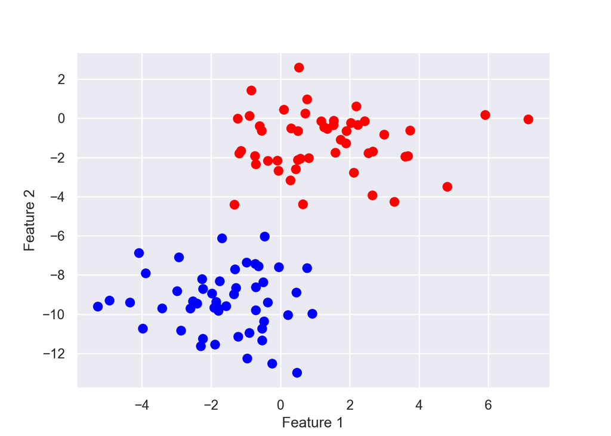

```python
plt.scatter(X[:, 0], X[:, 1], c=y, s=50, cmap='bwr'); plt.xlabel("Feature 1"); plt.ylabel("Feature 2")
plt.show()
```

```python
plt.close('all') # close the graph to create new ones down
```

Model assumption : “naive” = Gaussian. One extremely fast way to create a simple model is to assume that the data is described by a Gaussian distribution with no covariance between dimensions.

```python
fig, ax = plt.subplots()

ax.scatter(X[:, 0], X[:, 1], c=y, s=50, cmap='RdBu')
ax.set_title('Naive Bayes Model', size=14)
plt.xlabel("Feature 1"); plt.ylabel("Feature 2")

xlim = (-8, 8)
ylim = (-15, 5)

xg = np.linspace(xlim[0], xlim[1], 60)
yg = np.linspace(ylim[0], ylim[1], 40)
xx, yy = np.meshgrid(xg, yg)
Xgrid = np.vstack([xx.ravel(), yy.ravel()]).T

for label, color in enumerate(['red', 'blue']):
    mask = (y == label)
    mu, std = X[mask].mean(0), X[mask].std(0)
    P = np.exp(-0.5 * (Xgrid - mu) ** 2 / std ** 2).prod(1)
    Pm = np.ma.masked_array(P, P < 0.03)
    ax.pcolorfast(xg, yg, Pm.reshape(xx.shape), alpha=0.5,
                  cmap=color.title() + 's')
    ax.contour(xx, yy, P.reshape(xx.shape),
               levels=[0.01, 0.1, 0.5, 0.9],
               colors=color, alpha=0.2)
ax.set(xlim=xlim, ylim=ylim)
```

```
## [(-8.0, 8.0), (-15.0, 5.0)]
```

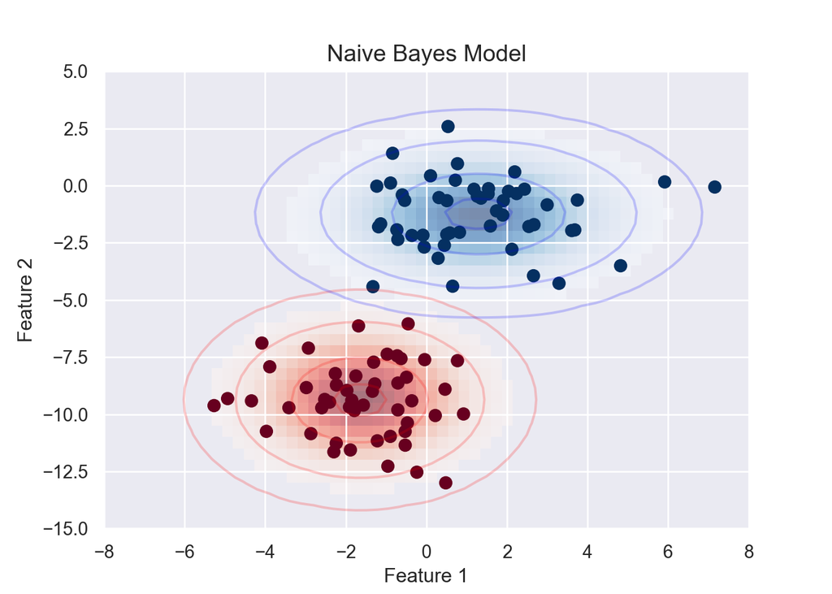

```python
plt.show()
#plt.close('all')
```

Let’s estimate the model and fit it to our data

```python
from sklearn.naive_bayes import GaussianNB
model = GaussianNB()
model.fit(X, y);

# check % of obs in each class
```

```
## GaussianNB()
```

```python
model.class_count_

# check model parameters
```

```
## array([50., 50.])
```

```python
model.theta_ # labelxfeatures
```

```
## array([[-1.64939095, -9.36891451],
##        [ 1.29327924, -1.24101221]])
```

```python
y_hat=model.predict(X)
from  sklearn.metrics import accuracy_score
accuracy_score(y,y_hat)
```

```
## 1.0
```

The Likelihood function used : $P(Feature_i \mid Label) = \frac{1}{\sqrt{2\pi\sigma^2_y}} \exp\left(-\frac{(x_i - \mu_y)^2}{2\sigma^2_y}\right)$

Now let’s generate some new data and predict the label:

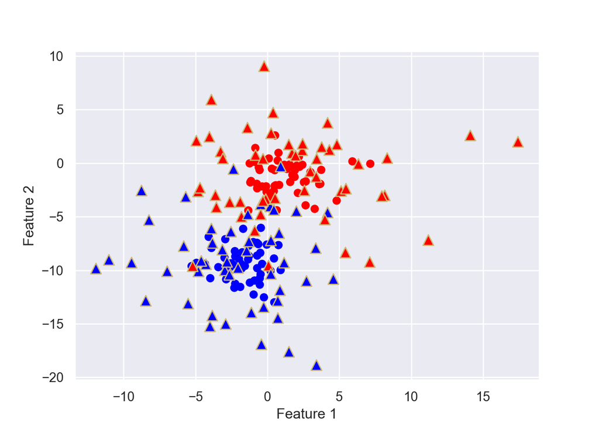

```python
rng = np.random.RandomState(0)
Xnew,ynew = make_blobs(100, 2, centers=2, random_state=2, cluster_std = 4)
plt.scatter(X[:,0], X[:,1], c=y, cmap='bwr')
plt.scatter(Xnew[:, 0], Xnew[:, 1], c=ynew, s=80, cmap="bwr",  edgecolor='y', marker='^'); plt.xlabel("Feature 1"); plt.ylabel("Feature 2")
plt.show()
```

```python
ynew_hat = model.predict(Xnew)
```

```python
plt.close('all')
plt.scatter(Xnew[:, 0], Xnew[:, 1], marker='^',c=ynew, s=70, cmap='bwr', alpha=0.3)
ax.set(xlim=xlim, ylim=ylim)
```

```
## [(-8.0, 8.0), (-15.0, 5.0)]
```

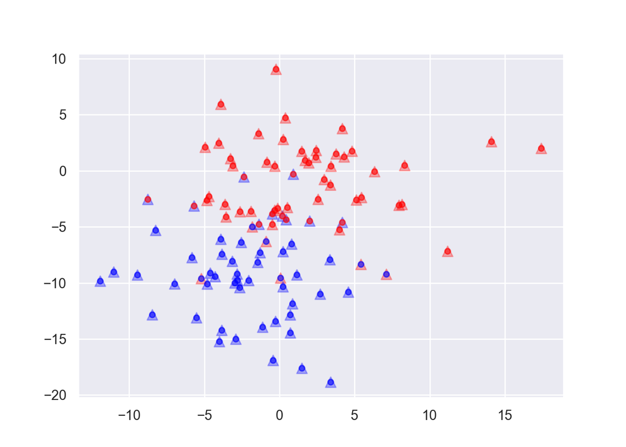

```python
plt.scatter(Xnew[:, 0], Xnew[:, 1],c=ynew_hat, s=20, cmap='bwr', alpha=0.6)
plt.show()
```

```python
plt.close('all')
```

```python
import pandas as p
yprob = model.predict_proba(Xnew)
df = p.DataFrame({'Feature1': Xnew[:,0], 'Feature2': Xnew[:,1], 'Prob_red':yprob[:,0].round(2), 'Actual_red':1-ynew})
df.head
```

```
## <bound method NDFrame.head of      Feature1   Feature2  Prob_red  Actual_red
## 0    4.590610 -10.824185      1.00           1
## 1  -11.917900  -9.847286      1.00           1
## 2    0.925714  -0.312643      0.00           1
## 3   -1.883766  -3.627211      0.02           0
## 4    2.429783   1.195330      0.00           0
## ..        ...        ...       ...         ...
## 95  -2.635390 -10.426211      1.00           1
## 96  -0.880135  -6.312433      0.99           0
## 97  -2.895671 -15.019550      1.00           1
## 98  -1.280063  -7.312065      1.00           1
## 99   3.399313  -1.278914      0.00           0
##
## [100 rows x 4 columns]>
```

```python
from sklearn.metrics import accuracy_score
accuracy_score(ynew, ynew_hat)

# holdouts
```

```
## 0.84
```

```python
from sklearn.model_selection import train_test_split, cross_val_score

X1, X2, y1, y2 = train_test_split(X, y, random_state=3, train_size = 0.5)

X1.shape # half of X
```

```
## (50, 2)
```

```python
model.fit(X1, y1)
```

```
## GaussianNB()
```

```python
y2_model=model.predict(X2)
accuracy_score(y2, y2_model)

# cross-validation
```

```
## 1.0
```

```python
y2_model=model.fit(X1,y1).predict(X2)
y1_model=model.fit(X2,y2).predict(X1)
accuracy_score(y1,y1_model); accuracy_score(y2,y2_model)
```

```
## 1.0
## 1.0
```

```python
cross_val_score(model, X, y, cv=2)
```

```
## array([1., 1.])
```

# Real data : iris database

```python
import seaborn as sns
iris = sns.load_dataset('iris')
iris.head()
```

```
##    sepal_length  sepal_width  petal_length  petal_width species
## 0           5.1          3.5           1.4          0.2  setosa
## 1           4.9          3.0           1.4          0.2  setosa
## 2           4.7          3.2           1.3          0.2  setosa
## 3           4.6          3.1           1.5          0.2  setosa
## 4           5.0          3.6           1.4          0.2  setosa
```

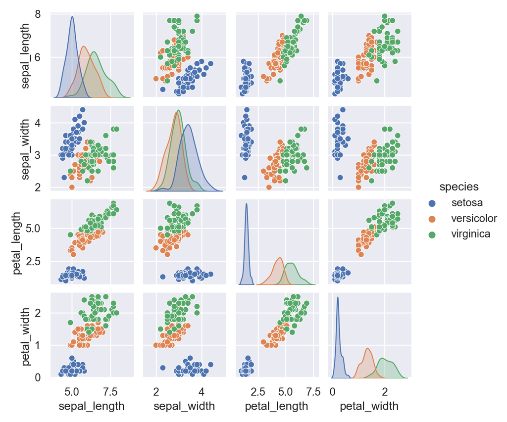

```python
import seaborn as sns; sns.set()
sns.pairplot(iris, hue='species', size=1.5);
plt.show()

# prepare x array with data
```

```python
X_iris = iris.drop('species', axis=1)
X_iris.shape

# prepare y vector with labels
```

```
## (150, 4)
```

```python
y_iris = iris['species']
y_iris.shape
```

```
## (150,)
```

```python
Xtrain, Xtest, ytrain, ytest = train_test_split(X_iris, y_iris,
                                                random_state=1)

model = GaussianNB()
model.fit(Xtrain, ytrain)                  #  fit model to data
```

```
## GaussianNB()
```

```python
y_model = model.predict(Xtest)             #  predict on new data
accuracy_score(ytest, y_model)
```

```
## 0.9736842105263158
```

```python
cross_val_score(model, X_iris, y_iris, cv=5)
```

```
## array([0.93333333, 0.96666667, 0.93333333, 0.93333333, 1.        ])
```